# Practical Machine Learning - Project

Hwan Sohn

9/25/2019

# Overview

From the project instruction and the provided data, we predict the manner in which the 6 participants did the exercise. In this report, we describe 1) how we built our model, 2)how we used cross validation, 3) what we think the expected out of sample error is, and 4) why we made the choice. Also we use the selected prediction model to predict 20 different test cases which can be used for the Project Prediction Quiz.

## Coding Environment

For the reproducibility, we provided the R coding environments with packages information.  
R version 3.6.1 (2019-07-05)  
Platform: x86_64-w64-mingw32/x64 (64-bit)  
Running under: Windows 10 x64 (build 15063)

## Loaded packages:

Caret(6.0.84), Hmisc(4.2.0), rattle(5.2.0), AppliedPredictiveModel, CORELearn(1.53.1),pgmm(1.2.3), rpart(4.1.15), ElemStatLearn(2015.6.26.2), ggplot2(3.2.1), gbm(2.1.5), e1071(1.7.2), forecast(8.9), randomForest(4.6.14)

```r
# loaded packages
library(caret)
```

```r
library(ggplot2)
library(rpart)
library(rattle)
library(randomForest)
set.seed(2341)
```

# Input Data

## Data Sources

We get the data from the following sites which are provided by the project instruction.  
Training data: https://d396qusza40orc.cloudfront.net/predmachlearn/pml-training.csv  
Test data: https://d396qusza40orc.cloudfront.net/predmachlearn/pml-testing.csv

## read csv file without data reducing

```r
training.csv = read.csv("https://d396qusza40orc.cloudfront.net/predmachlearn/pml-training.csv",strip.white=TRUE, na.strings = c("NA", "", "#DIV/0!"))
testing.csv = read.csv("https://d396qusza40orc.cloudfront.net/predmachlearn/pml-testing.csv",strip.white=TRUE, na.strings = c("NA", "", "#DIV/0!"))
dim(training.csv)
```

```
## [1] 19622   160
```

```r
dim(testing.csv)
```

```
## [1]  20 160
```

# Data reducing

Since the data size is large, it is better to reduce the size as much as possible. We remove NA valued variables, near zero variance variables, and non-predictor variables, After removing the NA related variables, we can reduce the variables from 160 to 60 which is a big reducing. Another thing we can reduce the data size is about near zero variance variables. After removing near zero variance variables, it reduces 1 variable only. We think this reducing is somewhat related to NA variable reducing. So many variables are already removed by the NA reducing. Anyway, this is also a way to reducing data size in general. For removing non-predictor columns, we found the column 1 to 7 from the csv files are not directly contribute to prediction. So we remove the columns. So the final variables are reduced to 52.

## 1) remove NA

```r
# remove white space, "NA", "", "#DIV/0!" at read.csv()
training_data <- training.csv[,colSums(is.na(training.csv))==0]
testing_data <- testing.csv[,colSums(is.na(testing.csv))==0]
dim(training_data)
```

```
## [1] 19622    60
```

```r
dim(testing_data)
```

```
## [1] 20 60
```

## 2) remove near zero variance variables

```r
nzv_var <- nearZeroVar(training_data)
training_data <- training_data[, -nzv_var]
testing_data <- testing_data[, -nzv_var]
dim(training_data)
```

```
## [1] 19622    59
```

```r
dim(testing_data)
```

```
## [1] 20 59
```

## 3) Remove non-prediction related columns

```r
# Remove non-prediction related columns such as index, subject, timestamp, window etc.
# "","user_name","raw_timestamp_part_1","raw_timestamp_part_2","cvtd_timestamp","new_window","num_window",
training_data <-  training_data[, -(1:7)]
testing_data <- testing_data[, -(1:7)]
dim(training_data)
```

```
## [1] 19622    52
```

```r
dim(testing_data)
```

```
## [1] 20 52
```

# Data Partition

For building the models, we split the training data into 2 parts (training, and testing with 75% and 25% respectively). And we use the testing_data from the csv file for validation sample.

```r
### split training data into 2 parts training(75%), testing(25%)
inTrain <- createDataPartition(training_data$classe, p=0.75, list=FALSE)
training <- training_data[inTrain,]
testing <- training_data[-inTrain,]
dim(training)
```

```
## [1] 14718    52
```

```r
dim(testing)
```

```
## [1] 4904   52
```

# Cross validation

For the cross validation, we first consider how we split the training data into training and testing. When we prepare input data, we already splitted the original pml-training.csv into training and testing parts(75%, 25%). In addition to the split, we use resampling method with k-fold cross validation in trainControl() function. If k is large enough, we will have less biased model in general. We applied this method to build gbm(Gradiant Boosting Model) and rf(Random Forest) models.

```r
fit_control <- trainControl(
    method = "cv",  # resampling method
    number = 3,     # number of resampling iterations
    )
```

# Model Building

## 1) decition tree model (rpart)

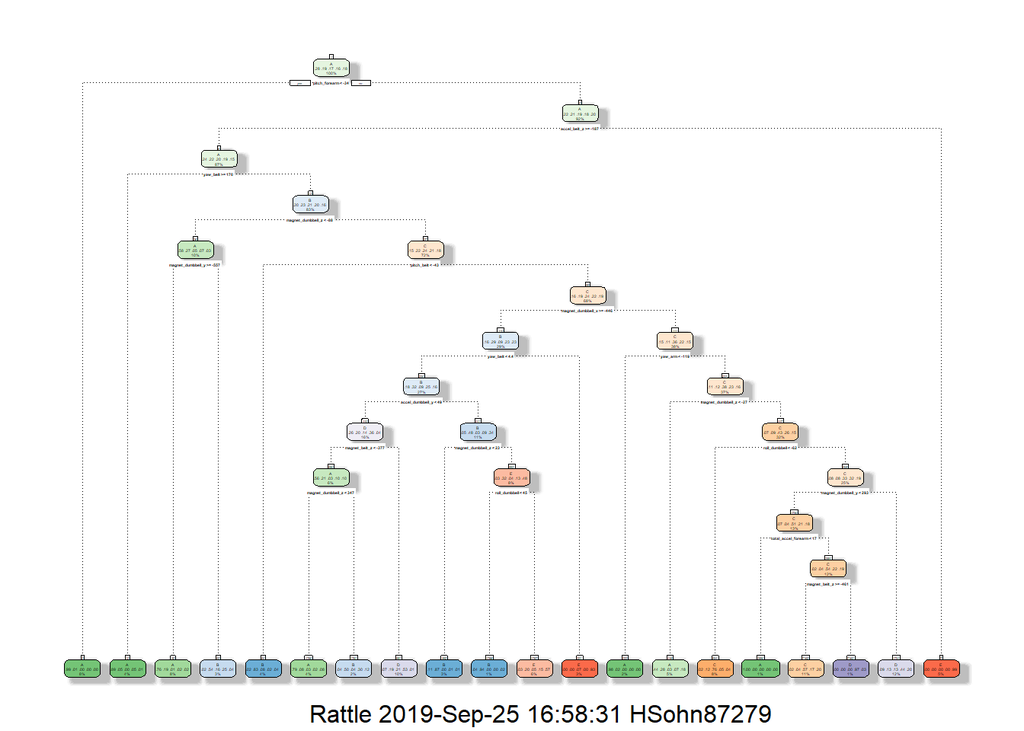

```r
set.seed(2341)
dt_fit <- rpart(classe ~ ., data = training, method="class")
# plot with facyRpartPlot
fancyRpartPlot(dt_fit)
```

```r
# build using train() function, but this method is only for my own experiment with the same fit_control,
# the result is similar but takes longer time
# dt_fit <- train(classe ~ ., data=training, method="rpart", trControl=fit_control, tuneLength=10)

# prediction of dtm model on testing
pred_dt <- predict(dt_fit, newdata = testing, type="class")
cm_dt <- confusionMatrix(pred_dt, testing$classe)
cm_dt
```

```
## Confusion Matrix and Statistics
##
##           Reference
## Prediction    A    B    C    D    E
##          A 1234  164   22   43   72
##          B   32  495   47   56   31
##          C   26   59  579  127  133
##          D   93  157  185  517  114
##          E   10   74   22   61  551
##
## Overall Statistics
##
##                Accuracy : 0.6884
##                  95% CI : (0.6752, 0.7014)
##     No Information Rate : 0.2845
##     P-Value [Acc > NIR] : < 2.2e-16
##
##                   Kappa : 0.6053
##
##  Mcnemar's Test P-Value : < 2.2e-16
##
## Statistics by Class:
##
##                      Class: A Class: B Class: C Class: D Class: E
## Sensitivity            0.8846   0.5216   0.6772   0.6430   0.6115
## Specificity            0.9142   0.9580   0.9148   0.8661   0.9583
## Pos Pred Value         0.8039   0.7489   0.6266   0.4850   0.7674
## Neg Pred Value         0.9522   0.8930   0.9307   0.9252   0.9164
## Prevalence             0.2845   0.1935   0.1743   0.1639   0.1837
## Detection Rate         0.2516   0.1009   0.1181   0.1054   0.1124
## Detection Prevalence   0.3130   0.1348   0.1884   0.2174   0.1464
## Balanced Accuracy      0.8994   0.7398   0.7960   0.7546   0.7849
```

## 2) Gradient Boosted Model (gbm)

```r
set.seed(2341)
gbm_fit <- train(classe ~ ., data=training, method="gbm", trControl=fit_control, verbose=FALSE)
gbm_fit$finalModel
```

```
## A gradient boosted model with multinomial loss function.
## 150 iterations were performed.
## There were 51 predictors of which 51 had non-zero influence.
```

```r
# prediction of gbm on testing
pred_gbm <- predict(gbm_fit, newdata=testing)
cm_gbm <- confusionMatrix(pred_gbm, testing$classe)
cm_gbm
```

```
## Confusion Matrix and Statistics
##
##           Reference
## Prediction    A    B    C    D    E
##          A 1361   23    0    0    2
##          B   24  895   32    2    8
##          C    9   29  807   32   13
##          D    0    0   14  765   11
##          E    1    2    2    5  867
##
## Overall Statistics
##
##                Accuracy : 0.9574
##                  95% CI : (0.9513, 0.9629)
##     No Information Rate : 0.2845
##     P-Value [Acc > NIR] : < 2.2e-16
##
##                   Kappa : 0.9461
##
##  Mcnemar's Test P-Value : NA
##
## Statistics by Class:
##
##                      Class: A Class: B Class: C Class: D Class: E
## Sensitivity            0.9756   0.9431   0.9439   0.9515   0.9623
## Specificity            0.9929   0.9833   0.9795   0.9939   0.9975
## Pos Pred Value         0.9820   0.9313   0.9067   0.9684   0.9886
## Neg Pred Value         0.9903   0.9863   0.9880   0.9905   0.9916
## Prevalence             0.2845   0.1935   0.1743   0.1639   0.1837
## Detection Rate         0.2775   0.1825   0.1646   0.1560   0.1768
## Detection Prevalence   0.2826   0.1960   0.1815   0.1611   0.1788
## Balanced Accuracy      0.9843   0.9632   0.9617   0.9727   0.9799
```

## 3) random forest model (rf)

```r
set.seed(2341)
rf_fit <- train(classe ~., data=training, method="rf", trControl=fit_control, verbose=FALSE)
rf_fit$finalModel
```

```
##
## Call:
##  randomForest(x = x, y = y, mtry = param$mtry, verbose = FALSE)
##                Type of random forest: classification
##                      Number of trees: 500
## No. of variables tried at each split: 26
##
##         OOB estimate of  error rate: 0.63%
## Confusion matrix:
##      A    B    C    D    E  class.error
## A 4182    2    1    0    0 0.0007168459
## B   20 2822    5    0    1 0.0091292135
## C    0   14 2546    7    0 0.0081807557
## D    0    0   27 2382    3 0.0124378109
## E    0    0    3    9 2694 0.0044345898
```

```r
# prediction of rf on testing
pred_rf <- predict(rf_fit, newdata=testing)
cm_rf <- confusionMatrix(pred_rf, testing$classe)
cm_rf
```

```
## Confusion Matrix and Statistics
##
##           Reference
## Prediction    A    B    C    D    E
##          A 1393    5    0    0    0
##          B    1  938    2    0    0
##          C    0    6  849    8    2
##          D    0    0    4  795    2
##          E    1    0    0    1  897
##
## Overall Statistics
##
##                Accuracy : 0.9935
##                  95% CI : (0.9908, 0.9955)
##     No Information Rate : 0.2845
##     P-Value [Acc > NIR] : < 2.2e-16
##
##                   Kappa : 0.9917
##
##  Mcnemar's Test P-Value : NA
##
## Statistics by Class:
##
##                      Class: A Class: B Class: C Class: D Class: E
## Sensitivity            0.9986   0.9884   0.9930   0.9888   0.9956
## Specificity            0.9986   0.9992   0.9960   0.9985   0.9995
## Pos Pred Value         0.9964   0.9968   0.9815   0.9925   0.9978
## Neg Pred Value         0.9994   0.9972   0.9985   0.9978   0.9990
## Prevalence             0.2845   0.1935   0.1743   0.1639   0.1837
## Detection Rate         0.2841   0.1913   0.1731   0.1621   0.1829
## Detection Prevalence   0.2851   0.1919   0.1764   0.1633   0.1833
## Balanced Accuracy      0.9986   0.9938   0.9945   0.9937   0.9975
```

## plot for rf_fit model

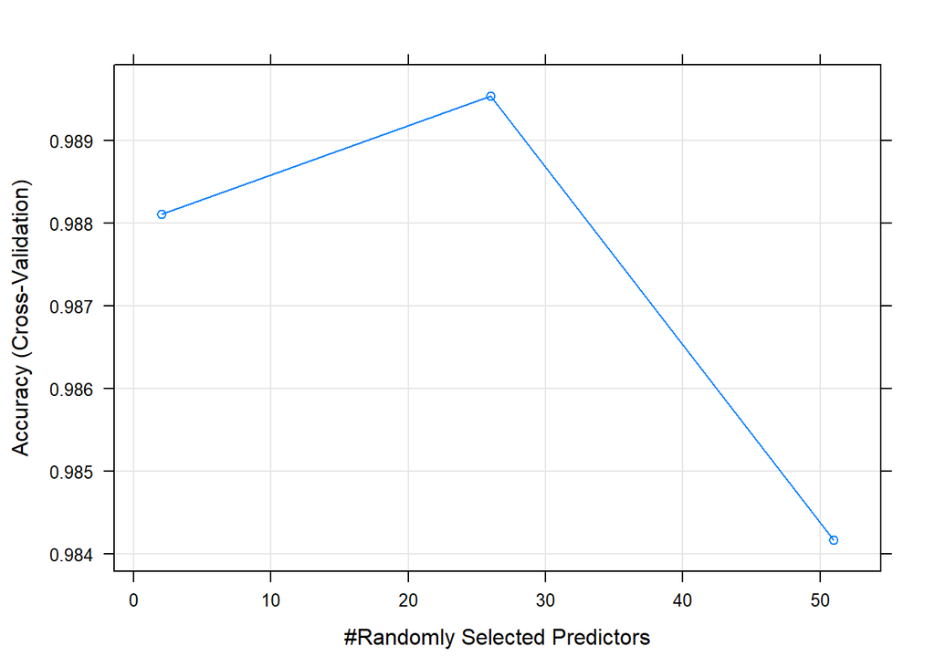

```r
plot(rf_fit)
```

# Choice of best model

Among the three models, we compare the accuracies. And the random forest model is the most accurate. So the our choice should be Random Forest model (rf_fit). From our best model, we get important variables from varImp(rf_fit). From this, we are able to suggest which feature is more important etc.

## Accuracy comparison of 3 models

```r
Accuracies <- data.frame(
  Model = c('dt', 'gbm', 'rf'),
  Accuracy = rbind(cm_dt$overall[1], cm_gbm$overall[1], cm_rf$overall[1])
)
Accuracies
```

```
##   Model  Accuracy
## 1    dt 0.6884176
## 2   gbm 0.9573817
## 3    rf 0.9934747
```

## Important features

```r
varImp(rf_fit)
```

```
## rf variable importance
##
##   only 20 most important variables shown (out of 51)
##
##                      Overall
## yaw_belt              100.00
## pitch_forearm          82.09
## pitch_belt             69.42
## magnet_dumbbell_z      62.70
## magnet_dumbbell_y      54.11
## roll_forearm           51.65
## accel_belt_z           39.65
## accel_dumbbell_y       28.14
## magnet_belt_z          26.66
## magnet_dumbbell_x      25.07
## gyros_belt_z           24.94
## magnet_belt_y          23.42
## roll_dumbbell          23.36
## accel_forearm_x        22.30
## accel_dumbbell_z       18.22
## magnet_belt_x          17.62
## total_accel_dumbbell   17.21
## magnet_forearm_z       16.94
## yaw_arm                15.04
## accel_forearm_z        13.51
```

# Quiz:

## Answer (predict) the quiz

From the selected model, we answer(predict) the quiz using testing_data which came from pml-testing.csv.

```r
# now apply the selected model to testing_data to answer(predict) the Quiz
pred_quiz <- predict(rf_fit, newdata = testing_data)
pred_quiz
```

```
##  [1] B A B A A E D B A A B C B A E E A B B B
## Levels: A B C D E
```

## Answer with a better format

```r
pred_quiz <- predict(rf_fit, newdata=testing_data)
quiz_Results <- data.frame(
  problem_id=testing_data$problem_id,
  predicted=pred_quiz
)
print(quiz_Results)
```

```
##    problem_id predicted
## 1           1         B
## 2           2         A
## 3           3         B
## 4           4         A
## 5           5         A
## 6           6         E
## 7           7         D
## 8           8         B
## 9           9         A
## 10         10         A
## 11         11         B
## 12         12         C
## 13         13         B
## 14         14         A
## 15         15         E
## 16         16         E
## 17         17         A
## 18         18         B
## 19         19         B
## 20         20         B
```

## Quiz result:

Quiz passed with 20/20

# Reference

The caret package: http://topepo.github.io/caret/index.html  
Tree-based models: https://www.statmethods.net/advstats/cart.html